# Ford GoBike System Data

**This data set includes information about individual rides made in a bike-sharing system covering the greater San Francisco Bay area.**

### Data Wrangling

```python
#display data type of data
df.info()
```

```
<class 'pandas.core.frame.DataFrame'>
RangeIndex: 183412 entries, 0 to 183411
Data columns (total 16 columns):
 #   Column                   Non-Null Count   Dtype
---  ------                   --------------   -----
 0   duration_sec             183412 non-null  int64
 1   start_time               183412 non-null  object
 2   end_time                 183412 non-null  object
 3   start_station_id         183215 non-null  float64
 4   start_station_name       183215 non-null  object
 5   start_station_latitude   183412 non-null  float64
 6   start_station_longitude  183412 non-null  float64
 7   end_station_id           183215 non-null  float64
 8   end_station_name         183215 non-null  object
 9   end_station_latitude     183412 non-null  float64
 10  end_station_longitude    183412 non-null  float64
 11  bike_id                  183412 non-null  int64
 12  user_type                183412 non-null  object
 13  member_birth_year        175147 non-null  float64
 14  member_gender            175147 non-null  object
 15  bike_share_for_all_trip  183412 non-null  object
dtypes: float64(7), int64(2), object(7)
memory usage: 22.4+ MB
```

```python
#find null values in the data
df.isna().sum()
```

```
duration_sec                  0
start_time                    0
end_time                      0
start_station_id            197
start_station_name          197
start_station_latitude        0
start_station_longitude       0
end_station_id              197
end_station_name            197
end_station_latitude          0
end_station_longitude         0
bike_id                       0
user_type                     0
member_birth_year          8265
member_gender              8265
bike_share_for_all_trip       0
dtype: int64
```

```python
# check number of rows and columns in data
df.shape
```

```
(183412, 16)
```

```python
df.isna().sum()
```

```
duration_sec               0
start_time                 0
end_time                   0
start_station_id           0
start_station_name         0
start_station_latitude     0
start_station_longitude    0
end_station_id             0
end_station_name           0
end_station_latitude       0
end_station_longitude      0
bike_id                    0
user_type                  0
member_birth_year          0
member_gender              0
bike_share_for_all_trip    0
dtype: int64
```

```python
### Clean age, find inappropraite age in the birth year column
```

```python
df.member_birth_year.describe()
```

```
count    174952.000000
mean       1984.803135
std          10.118731
min        1878.000000
25%        1980.000000
50%        1987.000000
75%        1992.000000
max        2001.000000
Name: member_birth_year, dtype: float64
```

# Exploratory Data Analysis

**Univariate Exploration**

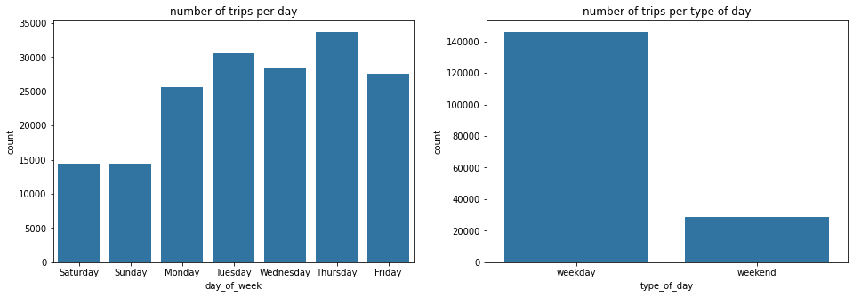

```python
# frequency of trips across the week
plt.figure(figsize = [16, 5])
base_color = sb.color_palette()[0]     # to make chart one color
days = (  'Saturday' , 'Sunday' , 'Monday' , 'Tuesday' , 'Wednesday' , 'Thursday' , 'Friday' )


plt.subplot(1, 2, 1)
sb.countplot(data= df , x='day_of_week' , color=base_color , order = days)
plt.title('number of trips per day')


plt.subplot(1, 2, 2)
sb.countplot(data= df , x='type_of_day' , color=base_color)
plt.title('number of trips per type of day');
```

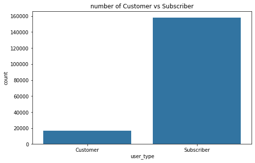

```python
plt.figure(figsize = [8, 5])
base_color = sb.color_palette()[0]

sb.countplot(data= df , x='user_type' , color=base_color )
plt.title('number of Customer vs Subscriber') ;
```

This graph shows; Number of subscribers is more than Customers

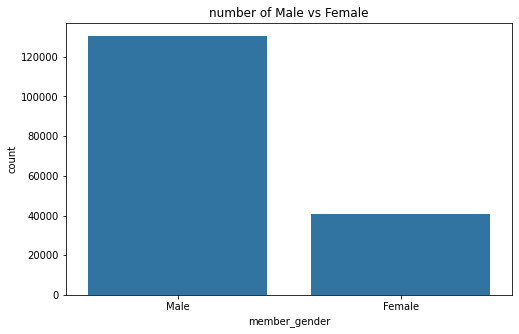

```python
plt.figure(figsize = [8, 5])
base_color = sb.color_palette()[0]
gender = ( 'Male' , 'Female' )

sb.countplot(data= df , x='member_gender' , color=base_color , order = gender )
plt.title('number of Male vs Female');
```

This graph shows there are more male compared to female

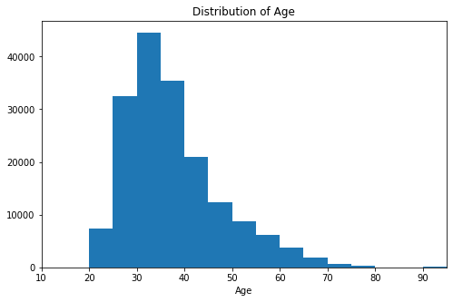

```python
# distribution of age
plt.figure(figsize = [8, 5])
bins_x = np.arange(10, df['age'].max()+5, 5)

plt.hist( data= df , x='age', bins = bins_x  )
plt.title('Distribution of Age')
plt.xlabel('Age')
plt.xlim((10,95)) ;
```

This graphs shows; The most age distributions is within 30s

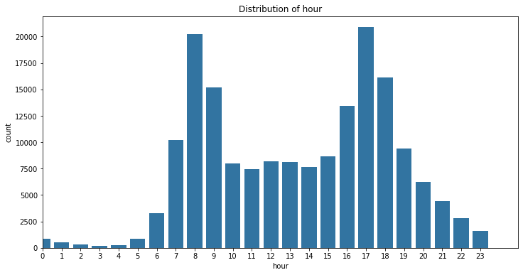

```python
# distribution of hour
plt.figure(figsize = [12, 6])
bins_x = np.arange(0, df['hour'].max()+1, 1)

sb.countplot( data= df , x='hour' , color=base_color )
plt.title('Distribution of hour')
plt.xlabel('hour')
plt.xlim((0,25));
```

This hraph shows rush hour is between 7am to 9am and 4pm to 6pm

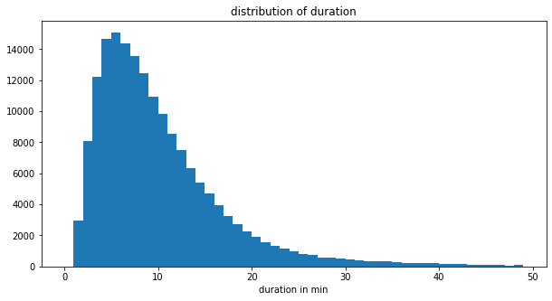

```python
# distribution of duration
plt.figure(figsize = [10, 5])
bins_x = np.arange(0,50, 1)

plt.hist( data= df , x='duration_min', bins = bins_x  )
plt.title('distribution of duration')
plt.xlabel('duration in min');
```

This graph shows; Most rides are taken between 3min and 20min

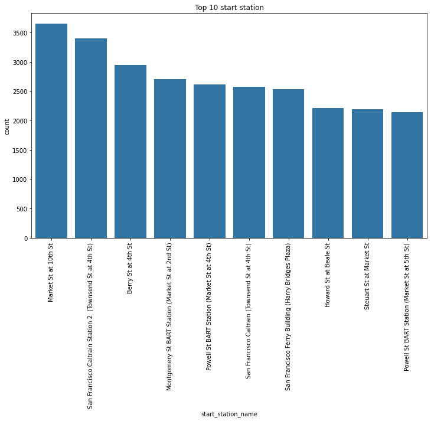

```python
most_10_station = df['start_station_name'].value_counts().head(10).index

# Frequency of top start stations
plt.figure(figsize = [12, 7])
base_color = sb.color_palette()[0]
plt.xticks(rotation=90)

sb.countplot(data= df , x='start_station_name' , color=base_color , order = most_10_station )
plt.title('Top 10 start station');
```

## Bivariate Exploration

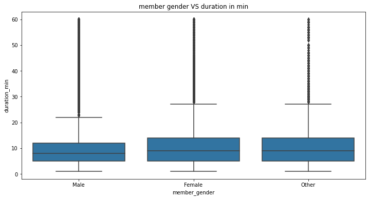

```python
# distribution of duration in min. Vs. gender:
df_duration = df.query( " duration_min <= 60")
plt.figure(figsize = [12, 6])
base_color = sb.color_palette()[0]
sb.boxplot(data=df_duration , x='member_gender' , y='duration_min' , color=base_color)
plt.title('member gender VS duration in min') ;
```

this graph shows the trip duration is almost the same for all genders

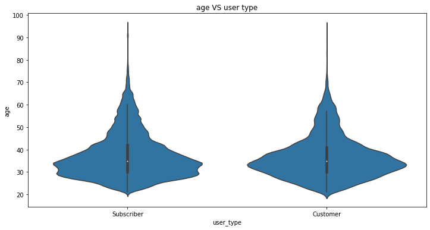

```python
# distribution of age Vs gender user type
df_duration = df.query( " duration_min <= 60")
plt.figure(figsize = [12, 6])
base_color = sb.color_palette()[0]
sb.violinplot(data=df_duration , x='user_type' , y='age' , color=base_color)
plt.title('age VS user type');
```

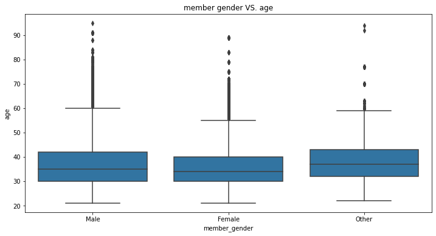

```python
# distribution of age Vs. gender:
plt.figure(figsize = [12, 6])
base_color = sb.color_palette()[0]
sb.boxplot(data=df_duration , x='member_gender' , y='age' , color=base_color)
plt.title('member gender VS. age') ;
```

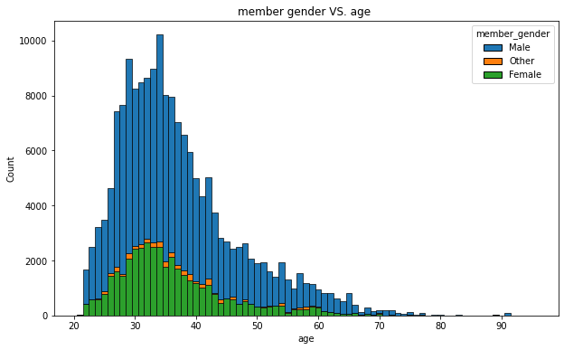

```python
# distribution of age Vs. gender:
plt.figure(figsize = [10, 6])

sb.histplot(data=df, x='age', stat='count', discrete=True, hue='member_gender', multiple='stack', alpha = 1)
plt.title('member gender VS. age ');
```

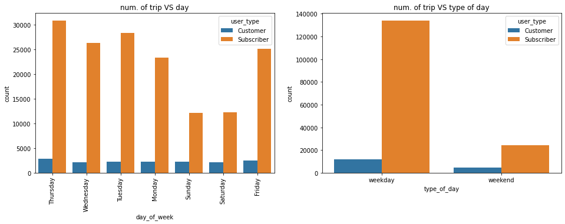

```python
# Plotting numberof trip Vs weekdays Vs the type of day:

plt.figure(figsize = [16, 5])

plt.subplot(1, 2, 1)
sb.countplot(data=df , x='day_of_week', hue='user_type')
plt.title('num. of trip VS day')
plt.xticks(rotation=90)

plt.subplot(1, 2, 2)
sb.countplot(data=df , x='type_of_day', hue='user_type')
plt.title('num. of trip VS type of day') ;
```

This graph shows; Number of customer is the same across all of weekday , but slightly less in the weekend Number of subscriber is greatly reduced in the weekend

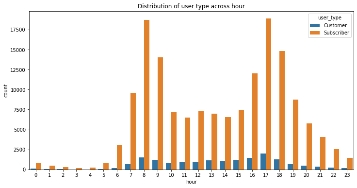

```python
# distribution of hour vs user type
plt.figure(figsize = [12, 6])

sb.countplot( data= df , x='hour' , hue = 'user_type')
plt.title('Distribution of user type across hour')
plt.xlabel('hour') ;
```

this graph shows;

subscriber will likely use Bike in rush hour and customer will use Bike in rush hour.

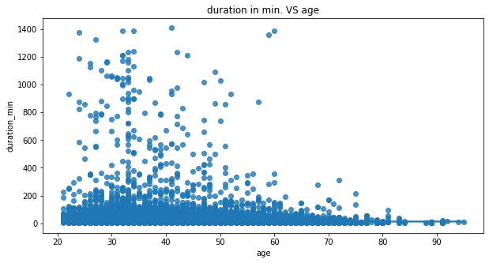

```python
# plotting duration in min. VS age
plt.figure(figsize = [10,5])
sb.regplot(data = df , x = 'age', y = 'duration_min');
plt.title('duration in min. VS age') ;
```

There is no relationship between duration in minute and age

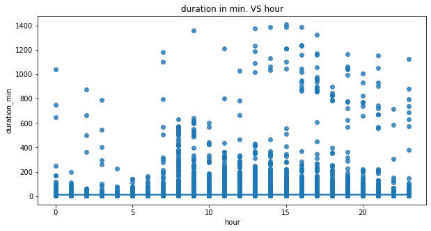

```python
# plotting duration in min. VS hour
plt.figure(figsize = [10, 5])
sb.regplot(data = df , x = 'hour', y = 'duration_min');
plt.title('duration in min. VS hour');
```

There is no relationship between hour and duration in min.

## Multivariate Exploration

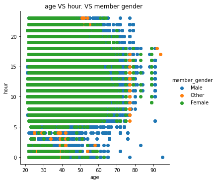

```python
# age VS hour. VS member gender
g = sb.FacetGrid(data = df, hue = 'member_gender', size = 5)
g.map(plt.scatter, 'age', 'hour')
g.add_legend()
plt.title('age VS hour. VS member gender ');
```

This graph shows;

There is no relationship between hour , age and gender.

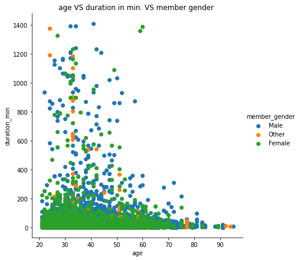

```python
# age VS duration in min. VS member gender
g = sb.FacetGrid(data = df, hue = 'member_gender', size = 6)
g.map(plt.scatter, 'age', 'duration_min')
g.add_legend()
plt.title('age VS duration in min. VS member gender ');
```

this graph shows; There is no relationship between duration in min. , age and gender .

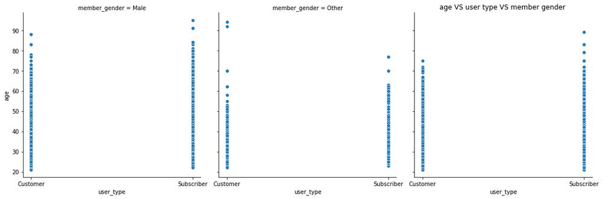

```python
# age VS user type VS member gender
g = sb.FacetGrid(data = df, col = 'member_gender', size = 5)
g.map(sb.scatterplot, 'user_type', 'age')
plt.title('age VS user type VS member gender ');
```

This graph shows no relationship

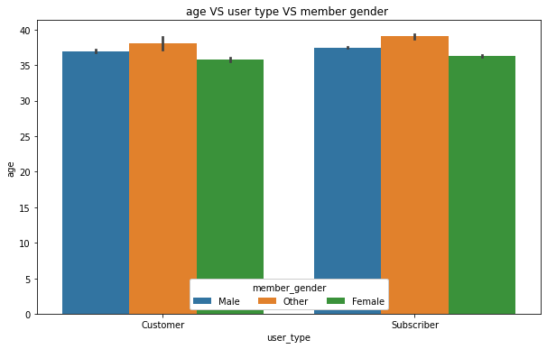

```python
plt.figure(figsize = [10,6])

ax = sb.barplot(data = df, x = 'user_type', y = 'age', hue = 'member_gender')
ax.legend(loc = 8, ncol = 3, framealpha = 1, title = 'member_gender')
plt.title('age VS user type VS member gender ') ;
```

This graph shows; distribution is nearly the same across customers and Subscribers

Findings

2-number of male much more than female.

5-the most ride take between 3 and 20 min

6-Rush hour between (7am : 9am) and (4pm : 6pm)